# MATH4432 Project 3: Nexperia Predictive Maintenance

# Project Introduction

#### Team Members (*Names in alphabetical order)

LI,Junrong (Build and test models) student id: 20328496, itsc: jlibz, kaggle id: junrongli ;

LIU,Cheng (Preliminary analysis and test models) student id: 20328927, itsc: cliubg, kaggle id: Cheng, LIU ;

ZHANG,Wenhao (Data processing, Preliminary analysis and test models) student id: 20253861, itsc: wzhangat, kaggle id: WENHAO ZHANG ;

#### Our task

In this notebook, we want to find out the possibilities of predicting the equipment failure in a period of future time using historical error information of selected machines. More detailedly, we hope to predict whether the equipment will fail (In the submission, we use 0 for successful operating, 1 for failure) on the following features of the previous days: for each of the 26 types of error messages:

1. the number of occurences in a day,
2. the mean of the occurences in a single day, and
3. the standard deviation of the occurences in a single day.

#### Our flow

Our experiment evolves as the following :

1. Data Preprocessing,
2. Preliminary Analysis,
3. Model Build And Test,
4. Prediction and Output.

# Data Introduction and Preprocessing

The dataset is given into 2 parts. One is the test data feature and the other one is training data. Both two sets contain error information given machine ID and time stamp. Each piece of error information is illustrated through 26 features and each feature is composed of 3 figures, count, mean and standard deviation.

Before importing data into Python for further processing, we reformat the data using R. The reason we use R is that it could provide a direct view of data inside and more convenient tools of dealing with Data.Frame data.

**Step 1** Revise the tags

```
After a simple glance at the data, we find that the column tags are given in 2 rows. As we want to adopt Data.Frame as a tool in Python, we combine two tags into one. Then the tags after revision would be "Machine","Date","Error Feature ID + Count","Error Feature ID + Mean", "Error Feature ID + SD". In the training data, there would be another tag called "Label".
```

**Step 2** Reformat the date

```
Since the date data are given into different formats originally, i.e "yyyy-m-d"/"yyyy-mm-dd",in order to unify the "Date" data, we use the R function "uclass" and "as.Date" to revise them. Then all the dates would be changed into the numbers of days between the base date "1970-01-01" and the original one. This is applied to both two datasets.
```

**Step 3** Clean the useless data

```
In the data, we find that some error information is given as following: Count = 1, Mean = NaN, SD = NaN. We treat this as useless, because this error is incomplete. Thus we wipe out this kind of information.
```

The R codes are shown as below:

```
rm(list=ls())

#Define file paths
feature_path = "/Users/hypnos/Desktop/Nexperia/Original Data/test_feature/"
train_path = "/Users/hypnos/Desktop/Nexperia/Original Data/training_data/"

output_path = "/Users/hypnos/Desktop/Nexperia/Cleaned Data/"

#Define file names
feature_namelist = c("Verification freq 1D, OW 1, PW 1_feature.csv","Verification freq 1D, OW 2, PW 1_feature.csv","Verification freq 1D, OW 4, PW 1_feature.csv","Verification freq 1D, OW 8, PW 1_feature.csv","Verification freq 1D, OW 16, PW 1_feature.csv")
train_namelist = c("Training freq 1D, OW 1, PW 1.csv","Training freq 1D, OW 2, PW 1.csv","Training freq 1D, OW 4, PW 1.csv","Training freq 1D, OW 8, PW 1.csv","Training freq 1D, OW 16, PW 1.csv")


for (each in feature_namelist){
  #Read feature data
  feature = read.csv(paste0(feature_path,each,sep=""))

  #Combine column tags
  for (i in 1:ncol(feature)){
    colnames(feature)[i] = paste0(colnames(feature)[i],feature[1,i],sep="")
    colnames(feature)[i] = substr(colnames(feature)[i],2,nchar(colnames(feature)[i]))
  }
  colnames(feature)[2] = "Machine"
  colnames(feature)[3] = "Date"

  #Clean incomplete data
  for (i in 1:nrow(feature)){
    for (j in 1:ncol(feature)){
      if (as.character(feature[i,j]) == "1.0"){
        feature[i,j] = ""
      }
    }
  }

  #Delete useless columns
  feature = as.data.frame(feature)
  feature <- feature[-c(1,2),]
  feature <- feature[,-1]

  #Revise dates
  for (i in feature["Date"]){
    i = unclass(as.Date(i))
  }
  feature["Date"]=as.data.frame(i)

  #File output
  write.csv(feature,file = paste0(output_path,each,sep=""), row.names = FALSE)
}

for (each in train_namelist){
  #Read feature data
  train = read.csv(paste0(train_path,each,sep=""))

  #Combine column tags
  for (i in 1:ncol(train)-1){
    colnames(train)[i] = paste0(colnames(train)[i],train[1,i],sep="")
    colnames(train)[i] = substr(colnames(train)[i],2,nchar(colnames(train)[i]))
  }
  colnames(train)[1] = "Machine"
  colnames(train)[2] = "Date"

  #Clean incomplete data
  for (i in 1:nrow(train)){
    for (j in 1:ncol(train)){
      if (as.character(train[i,j]) == "1.0"){
        train[i,j] = ""
      }
    }
  }

  #Revise dates
  train = as.data.frame(train)
  train <- train[-c(1,2),]
  for (i in train["Date"]){
    i = unclass(as.Date(i))
  }
  train["Date"]=as.data.frame(i)

  #File output
  write.csv(train,file = paste0(output_path,each,sep=""), row.names = FALSE)
}
```

# Data exploration and structure optimization

## Explore the Data Statistically（Python）

### Import Libraries and Data

```python
import pandas as pd
import sklearn.tree as tree
from xgboost import XGBClassifier
import numpy as np
import time
import os

import matplotlib.pyplot as plt
%matplotlib inline
import seaborn as sns

from sklearn.model_selection import train_test_split
from sklearn.metrics import accuracy_score
from sklearn.linear_model import LogisticRegression
from sklearn.multiclass import OneVsRestClassifier
from sklearn.svm import SVC

from sklearn.ensemble import (RandomForestClassifier, AdaBoostClassifier,
                              GradientBoostingClassifier, ExtraTreesClassifier)
from sklearn.cross_validation import KFold

#ignore warnings
import warnings

print("load data..")

train = pd.read_csv("Training freq 1D, OW 16, PW 1.csv")
test = pd.read_csv("Verification freq 1D, OW 16, PW 1_feature.csv")

print(train.info())
print(test.info())
```

```
load data..
<class 'pandas.core.frame.DataFrame'>
RangeIndex: 11551 entries, 0 to 11550
Data columns (total 84 columns):
Machine     11551 non-null object
Date        11551 non-null object
count       11290 non-null float64
vMean       10716 non-null float64
vStd        10716 non-null float64
count.1     10557 non-null float64
vMean.1     9335 non-null float64
vStd.1      9335 non-null float64
count.2     2142 non-null float64
vMean.2     1292 non-null float64
vStd.2      1292 non-null float64
count.3     1844 non-null float64
vMean.3     1511 non-null float64
vStd.3      1511 non-null float64
count.4     2613 non-null float64
vMean.4     2027 non-null float64
vStd.4      2027 non-null float64
count.5     8949 non-null float64
vMean.5     6637 non-null float64
vStd.5      6637 non-null float64
count.6     11551 non-null int64
vMean.6     11551 non-null float64
vStd.6      11551 non-null float64
count.7     1435 non-null float64
vMean.7     1190 non-null float64
vStd.7      1190 non-null float64
count.8     11551 non-null int64
vMean.8     11551 non-null float64
vStd.8      11551 non-null float64
count.9     11479 non-null float64
vMean.9     11376 non-null float64
vStd.9      11376 non-null float64
count.10    5468 non-null float64
vMean.10    3523 non-null float64
vStd.10     3523 non-null float64
count.11    7966 non-null float64
```

[output cut: 125 more lines]

```
count.23    105 non-null float64
vMean.23    73 non-null float64
vStd.23     73 non-null float64
count.24    73 non-null float64
vMean.24    72 non-null float64
vStd.24     72 non-null float64
count.25    73 non-null float64
vMean.25    72 non-null float64
vStd.25     72 non-null float64
count.26    107 non-null float64
vMean.26    107 non-null float64
vStd.26     107 non-null float64
dtypes: float64(76), int64(5), object(2)
memory usage: 2.1+ MB
None
```

### Number of Rows and Columns

```python
print(train.shape)
print("--------------------------------")
print(test.shape)
```

```
(11551, 84)
--------------------------------
(3283, 83)
```

### Column Names

```python
train.columns
```

```
Index(['Machine', 'Date', 'count', 'vMean', 'vStd', 'count.1', 'vMean.1',
       'vStd.1', 'count.2', 'vMean.2', 'vStd.2', 'count.3', 'vMean.3',
       'vStd.3', 'count.4', 'vMean.4', 'vStd.4', 'count.5', 'vMean.5',
       'vStd.5', 'count.6', 'vMean.6', 'vStd.6', 'count.7', 'vMean.7',
       'vStd.7', 'count.8', 'vMean.8', 'vStd.8', 'count.9', 'vMean.9',
       'vStd.9', 'count.10', 'vMean.10', 'vStd.10', 'count.11', 'vMean.11',
       'vStd.11', 'count.12', 'vMean.12', 'vStd.12', 'count.13', 'vMean.13',
       'vStd.13', 'count.14', 'vMean.14', 'vStd.14', 'count.15', 'vMean.15',
       'vStd.15', 'count.16', 'vMean.16', 'vStd.16', 'count.17', 'vMean.17',
       'vStd.17', 'count.18', 'vMean.18', 'vStd.18', 'count.19', 'vMean.19',
       'vStd.19', 'count.20', 'vMean.20', 'vStd.20', 'count.21', 'vMean.21',
       'vStd.21', 'count.22', 'vMean.22', 'vStd.22', 'count.23', 'vMean.23',
       'vStd.23', 'count.24', 'vMean.24', 'vStd.24', 'count.25', 'vMean.25',
       'vStd.25', 'count.26', 'vMean.26', 'vStd.26', 'result'],
      dtype='object')
```

### Data Types

```python
print(train.info())
print("-------------------------------------")
print(test.info())
```

```
<class 'pandas.core.frame.DataFrame'>
RangeIndex: 11551 entries, 0 to 11550
Data columns (total 84 columns):
Machine     11551 non-null object
Date        11551 non-null object
count       11290 non-null float64
vMean       10716 non-null float64
vStd        10716 non-null float64
count.1     10557 non-null float64
vMean.1     9335 non-null float64
vStd.1      9335 non-null float64
count.2     2142 non-null float64
vMean.2     1292 non-null float64
vStd.2      1292 non-null float64
count.3     1844 non-null float64
vMean.3     1511 non-null float64
vStd.3      1511 non-null float64
count.4     2613 non-null float64
vMean.4     2027 non-null float64
vStd.4      2027 non-null float64
count.5     8949 non-null float64
vMean.5     6637 non-null float64
vStd.5      6637 non-null float64
count.6     11551 non-null int64
vMean.6     11551 non-null float64
vStd.6      11551 non-null float64
count.7     1435 non-null float64
vMean.7     1190 non-null float64
vStd.7      1190 non-null float64
count.8     11551 non-null int64
vMean.8     11551 non-null float64
vStd.8      11551 non-null float64
count.9     11479 non-null float64
vMean.9     11376 non-null float64
vStd.9      11376 non-null float64
count.10    5468 non-null float64
vMean.10    3523 non-null float64
vStd.10     3523 non-null float64
count.11    7966 non-null float64
vMean.11    5880 non-null float64
```

[output cut: 125 more lines]

```
count.23    105 non-null float64
vMean.23    73 non-null float64
vStd.23     73 non-null float64
count.24    73 non-null float64
vMean.24    72 non-null float64
vStd.24     72 non-null float64
count.25    73 non-null float64
vMean.25    72 non-null float64
vStd.25     72 non-null float64
count.26    107 non-null float64
vMean.26    107 non-null float64
vStd.26     107 non-null float64
dtypes: float64(76), int64(5), object(2)
memory usage: 2.1+ MB
None
```

### Missing Data

How much Data is missing from the training and test datasets, how important is that data and how much data cleaning might be required.

```python
print(pd.isnull(train).sum())
```

```
Machine         0
Date            0
count         261
vMean         835
vStd          835
count.1       994
vMean.1      2216
vStd.1       2216
count.2      9409
vMean.2     10259
vStd.2      10259
count.3      9707
vMean.3     10040
vStd.3      10040
count.4      8938
vMean.4      9524
vStd.4       9524
count.5      2602
vMean.5      4914
vStd.5       4914
count.6         0
vMean.6         0
vStd.6          0
count.7     10116
vMean.7     10361
vStd.7      10361
count.8         0
vMean.8         0
vStd.8          0
count.9        72
            ...
vMean.17        2
vStd.17         2
count.18     6756
vMean.18     8632
vStd.18      8632
count.19    11341
vMean.19    11399
vStd.19     11399
count.20     4486
vMean.20     6578
vStd.20      6578
count.21     8967
vMean.21     9665
vStd.21      9665
count.22    11250
vMean.22    11266
vStd.22     11266
count.23    11249
vMean.23    11265
vStd.23     11265
count.24    11266
vMean.24    11266
vStd.24     11266
count.25    11262
vMean.25    11262
vStd.25     11262
count.26    11168
vMean.26    11168
vStd.26     11168
result         12
Length: 84, dtype: int64
```

### Observations on Missing Data

It appears to show thar there are numerous missing data. However in this project, there's no missing data, where blank cell represents nothing.

### Cleansing the Data

Since there exists some difference in datatype bwtween training set and testing set. Data cleansing is executed as follows:

```python
print("cleans the data...")

#fill in the null value with the mean value of this column
train["count.1"] = train["count.1"].fillna(train["count.1"].mean())
test["count.1"] = test["count.1"].fillna(test["count.1"].mean())

train["vMean.1"] = train["vMean.1"].fillna(train["vMean.1"].mean())
test["vMean.1"] = test["vMean.1"].fillna(test["vMean.1"].mean())

train["vStd.1"] = train["vStd.1"].fillna(train["vStd.1"].mean())
test["vStd.1"] = test["vStd.1"].fillna(test["vStd.1"].mean())


train["count.2"] = train["count.2"].fillna(train["count.2"].mean())
test["count.2"] = test["count.2"].fillna(test["count.2"].mean())

train["vMean.2"] = train["vMean.2"].fillna(train["vMean.2"].mean())
test["vMean.2"] = test["vMean.2"].fillna(test["vMean.2"].mean())

train["vStd.2"] = train["vStd.2"].fillna(train["vStd.2"].mean())
test["vStd.2"] = test["vStd.2"].fillna(test["vStd.2"].mean())


train["count.3"] = train["count.3"].fillna(train["count.3"].mean())
test["count.6"] = test["count.3"].fillna(test["count.3"].mean())

train["vMean.3"] = train["vMean.3"].fillna(train["vMean.3"].mean())
test["vMean.3"] = test["vMean.3"].fillna(test["vMean.3"].mean())

train["vStd.3"] = train["vStd.3"].fillna(train["vStd.3"].mean())
test["vStd.3"] = test["vStd.3"].fillna(test["vStd.3"].mean())


train["count.4"] = train["count.4"].fillna(train["count.4"].mean())
test["count.4"] = test["count.4"].fillna(test["count.4"].mean())

train["vMean.4"] = train["vMean.4"].fillna(train["vMean.4"].mean())
test["vMean.4"] = test["vMean.4"].fillna(test["vMean.4"].mean())

train["vStd.4"] = train["vStd.4"].fillna(train["vStd.4"].mean())
test["vStd.4"] = test["vStd.4"].fillna(test["vStd.4"].mean())


train["count.5"] = train["count.5"].fillna(train["count.5"].mean())
test["count.5"] = test["count.5"].fillna(test["count.5"].mean())

train["vMean.5"] = train["vMean.5"].fillna(train["vMean.5"].mean())
test["vMean.5"] = test["vMean.5"].fillna(test["vMean.5"].mean())

train["vStd.5"] = train["vStd.5"].fillna(train["vStd.5"].mean())
test["vStd.5"] = test["vStd.5"].fillna(test["vStd.5"].mean())


train["count.6"] = train["count.6"].fillna(train["count.6"].mean())
test["count.6"] = test["count.6"].fillna(test["count.6"].mean())

train["vMean.6"] = train["vMean.6"].fillna(train["vMean.6"].mean())
test["vMean.6"] = test["vMean.6"].fillna(test["vMean.6"].mean())

train["vStd.6"] = train["vStd.6"].fillna(train["vStd.6"].mean())
test["vStd.6"] = test["vStd.6"].fillna(test["vStd.6"].mean())


train["count.7"] = train["count.7"].fillna(train["count.7"].mean())
test["count.7"] = test["count.7"].fillna(test["count.7"].mean())

train["vMean.7"] = train["vMean.7"].fillna(train["vMean.7"].mean())
test["vMean.7"] = test["vMean.7"].fillna(test["vMean.7"].mean())

train["vStd.7"] = train["vStd.7"].fillna(train["vStd.7"].mean())
test["vStd.7"] = test["vStd.7"].fillna(test["vStd.7"].mean())


train["count.8"] = train["count.8"].fillna(train["count.8"].mean())
test["count.8"] = test["count.8"].fillna(test["count.8"].mean())

train["vMean.8"] = train["vMean.8"].fillna(train["vMean.8"].mean())
test["vMean.8"] = test["vMean.8"].fillna(test["vMean.8"].mean())

train["vStd.8"] = train["vStd.8"].fillna(train["vStd.8"].mean())
test["vStd.8"] = test["vStd.8"].fillna(test["vStd.8"].mean())


train["count.9"] = train["count.9"].fillna(train["count.9"].mean())
test["count.9"] = test["count.9"].fillna(test["count.9"].mean())

train["vMean.9"] = train["vMean.9"].fillna(train["vMean.9"].mean())
test["vMean.9"] = test["vMean.9"].fillna(test["vMean.9"].mean())

train["vStd.9"] = train["vStd.9"].fillna(train["vStd.9"].mean())
test["vStd.9"] = test["vStd.9"].fillna(test["vStd.9"].mean())


train["count.10"] = train["count.10"].fillna(train["count.10"].mean())
test["count.10"] = test["count.10"].fillna(test["count.10"].mean())

train["vMean.10"] = train["vMean.10"].fillna(train["vMean.10"].mean())
test["vMean.10"] = test["vMean.10"].fillna(test["vMean.10"].mean())

train["vStd.10"] = train["vStd.10"].fillna(train["vStd.10"].mean())
test["vStd.10"] = test["vStd.10"].fillna(test["vStd.10"].mean())


train["count.11"] = train["count.11"].fillna(train["count.11"].mean())
test["count.11"] = test["count.11"].fillna(test["count.11"].mean())

train["vMean.11"] = train["vMean.11"].fillna(train["vMean.11"].mean())
test["vMean.11"] = test["vMean.11"].fillna(test["vMean.11"].mean())

train["vStd.11"] = train["vStd.11"].fillna(train["vStd.11"].mean())
test["vStd.11"] = test["vStd.11"].fillna(test["vStd.11"].mean())


train["count.12"] = train["count.12"].fillna(train["count.12"].mean())
test["count.12"] = test["count.12"].fillna(test["count.12"].mean())

train["vMean.12"] = train["vMean.12"].fillna(train["vMean.12"].mean())
test["vMean.12"] = test["vMean.12"].fillna(test["vMean.12"].mean())

train["vStd.12"] = train["vStd.12"].fillna(train["vStd.12"].mean())
test["vStd.12"] = test["vStd.12"].fillna(test["vStd.12"].mean())


train["count.13"] = train["count.13"].fillna(train["count.13"].mean())
test["count.13"] = test["count.13"].fillna(test["count.13"].mean())

train["vMean.13"] = train["vMean.13"].fillna(train["vMean.13"].mean())
test["vMean.13"] = test["vMean.13"].fillna(test["vMean.13"].mean())

train["vStd.13"] = train["vStd.13"].fillna(train["vStd.13"].mean())
test["vStd.13"] = test["vStd.13"].fillna(test["vStd.13"].mean())


train["count.14"] = train["count.14"].fillna(train["count.14"].mean())
test["count.14"] = test["count.14"].fillna(test["count.14"].mean())

train["vMean.14"] = train["vMean.14"].fillna(train["vMean.14"].mean())
test["vMean.14"] = test["vMean.14"].fillna(test["vMean.14"].mean())

train["vStd.14"] = train["vStd.14"].fillna(train["vStd.14"].mean())
test["vStd.14"] = test["vStd.14"].fillna(test["vStd.14"].mean())


train["count.15"] = train["count.15"].fillna(train["count.15"].mean())
test["count.15"] = test["count.15"].fillna(test["count.15"].mean())

train["vMean.15"] = train["vMean.15"].fillna(train["vMean.15"].mean())
test["vMean.15"] = test["vMean.15"].fillna(test["vMean.15"].mean())

train["vStd.15"] = train["vStd.15"].fillna(train["vStd.15"].mean())
test["vStd.15"] = test["vStd.15"].fillna(test["vStd.15"].mean())


train["count.16"] = train["count.16"].fillna(train["count.16"].mean())
test["count.16"] = test["count.16"].fillna(test["count.16"].mean())

train["vMean.16"] = train["vMean.16"].fillna(train["vMean.16"].mean())
test["vMean.16"] = test["vMean.16"].fillna(test["vMean.16"].mean())

train["vStd.16"] = train["vStd.16"].fillna(train["vStd.16"].mean())
test["vStd.16"] = test["vStd.16"].fillna(test["vStd.16"].mean())


train["count.17"] = train["count.17"].fillna(train["count.17"].mean())
test["count.17"] = test["count.17"].fillna(test["count.17"].mean())

train["vMean.17"] = train["vMean.17"].fillna(train["vMean.17"].mean())
test["vMean.17"] = test["vMean.17"].fillna(test["vMean.17"].mean())

train["vStd.17"] = train["vStd.17"].fillna(train["vStd.17"].mean())
test["vStd.17"] = test["vStd.17"].fillna(test["vStd.17"].mean())


train["count.18"] = train["count.18"].fillna(train["count.18"].mean())
test["count.18"] = test["count.18"].fillna(test["count.18"].mean())

train["vMean.18"] = train["vMean.18"].fillna(train["vMean.18"].mean())
test["vMean.18"] = test["vMean.18"].fillna(test["vMean.18"].mean())

train["vStd.18"] = train["vStd.18"].fillna(train["vStd.18"].mean())
test["vStd.18"] = test["vStd.18"].fillna(test["vStd.18"].mean())


train["count.19"] = train["count.19"].fillna(train["count.19"].mean())
test["count.19"] = test["count.19"].fillna(test["count.19"].mean())

train["vMean.19"] = train["vMean.19"].fillna(train["vMean.19"].mean())
test["vMean.19"] = test["vMean.19"].fillna(test["vMean.19"].mean())

train["vStd.19"] = train["vStd.19"].fillna(train["vStd.19"].mean())
test["vStd.19"] = test["vStd.19"].fillna(test["vStd.19"].mean())


train["count.20"] = train["count.20"].fillna(train["count.20"].mean())
test["count.20"] = test["count.20"].fillna(test["count.20"].mean())

train["vMean.20"] = train["vMean.20"].fillna(train["vMean.20"].mean())
test["vMean.20"] = test["vMean.20"].fillna(test["vMean.20"].mean())

train["vStd.20"] = train["vStd.20"].fillna(train["vStd.20"].mean())
test["vStd.20"] = test["vStd.20"].fillna(test["vStd.20"].mean())


train["count"] = train["count"].fillna(train["count"].mean())
test["count"] = test["count"].fillna(test["count"].mean())

train["all_count"] = train["count"]+train["count.1"]+train["count.2"]+train["count.3"]+\
    train["count.4"]+train["count.5"]+train["count.6"]+train["count.7"]+train["count.8"]+\
    train["count.9"]+train["count.10"]+train["count.11"]+train["count.12"]+train["count.13"]+\
    train["count.14"]+train["count.15"]+train["count.16"]+train["count.17"]+train["count.18"]

test["all_count"] = test["count"]+test["count.1"]+test["count.2"]+test["count.3"]+\
    test["count.4"]+test["count.5"]+test["count.6"]+test["count.7"]+test["count.8"]+\
    test["count.9"]+test["count.10"]+test["count.11"]+test["count.12"]+test["count.13"]+\
    test["count.14"]+test["count.15"]+test["count.16"]+test["count.17"]+test["count.18"]


train["all_count"] = train["all_count"].fillna(0)
test["all_count"] = test["all_count"].fillna(0)

train["result"] = train["result"].fillna("TRUE")

train["result"] = train["result"].apply(lambda x : 1 if x else 0)
```

```
cleans the data...
```

### Statistical Overview of the Data

```python
train.describe()
```

|  | count | vMean | vStd | count.1 | vMean.1 | vStd.1 | count.2 | vMean.2 | vStd.2 | count.3 | ... | vMean.24 | vStd.24 | count.25 | vMean.25 | vStd.25 | count.26 | vMean.26 | vStd.26 | result | all_count |
| --- | --- | --- | --- | --- | --- | --- | --- | --- | --- | --- | --- | --- | --- | --- | --- | --- | --- | --- | --- | --- | --- |
| count | 11551.000000 | 1.071600e+04 | 10716.000000 | 11551.000000 | 1.155100e+04 | 11551.000000 | 11551.000000 | 1.155100e+04 | 11551.000000 | 11551.000000 | ... | 285.000000 | 285.000000 | 289.000000 | 289.000000 | 289.000000 | 383.000000 | 383.000000 | 383.000000 | 11551.000000 | 11551.000000 |
| mean | 22.618246 | 1.187892e+05 | 115351.125941 | 11.710619 | 1.712397e+05 | 127002.025423 | 16.844071 | 5.052368e+04 | 56461.418740 | 21.497289 | ... | 16935.077105 | 41328.717175 | 93.564014 | 16777.028750 | 38769.877944 | 2184.814621 | 906.715382 | 3721.367491 | 0.074885 | 11044.526927 |
| std | 33.167303 | 1.426898e+05 | 90645.463007 | 20.975378 | 1.750028e+05 | 98029.463388 | 16.244272 | 4.425117e+04 | 27251.293662 | 12.563436 | ... | 17792.260675 | 27890.056061 | 59.863939 | 12222.445904 | 22283.394435 | 1652.409071 | 5880.643454 | 23527.251843 | 0.263218 | 26628.659924 |
| min | 1.000000 | 1.387900e-02 | 0.000000 | 1.000000 | 2.497154e+00 | 0.000000 | 1.000000 | 6.036900e-02 | 0.000000 | 1.000000 | ... | 832.702931 | 0.000000 | 3.000000 | 246.831407 | 77.650612 | 9.000000 | 0.407164 | 0.012730 | 0.000000 | 360.041279 |
| 25% | 5.000000 | 3.403211e+04 | 51237.860658 | 3.000000 | 5.864196e+04 | 63750.832750 | 16.844071 | 5.052368e+04 | 56461.418740 | 21.497289 | ... | 9579.279273 | 22112.424970 | 46.000000 | 9830.533790 | 24332.692900 | 72.500000 | 184.811590 | 736.827382 | 0.000000 | 1115.105355 |
| 50% | 12.000000 | 7.391406e+04 | 95431.522720 | 6.000000 | 1.498042e+05 | 127002.025423 | 16.844071 | 5.052368e+04 | 56461.418740 | 21.497289 | ... | 13878.494610 | 33460.147450 | 83.000000 | 13305.961010 | 33584.074570 | 2208.000000 | 375.644879 | 1345.683487 | 0.000000 | 1499.278156 |
| 75% | 25.000000 | 1.457621e+05 | 156819.396425 | 11.710619 | 1.856401e+05 | 161588.468100 | 16.844071 | 5.052368e+04 | 56461.418740 | 21.497289 | ... | 21809.085760 | 54055.553650 | 124.000000 | 19565.126030 | 47245.357080 | 3438.500000 | 517.954600 | 2442.903126 | 0.000000 | 2459.564635 |
| max | 525.000000 | 1.354103e+06 | 671869.955600 | 292.000000 | 1.364422e+06 | 688060.751100 | 372.000000 | 1.307708e+06 | 602730.832000 | 222.000000 | ... | 271086.215400 | 235252.064800 | 269.000000 | 76194.710350 | 119101.399100 | 5466.000000 | 66917.025120 | 267666.245800 | 1.000000 | 331056.660062 |

8 rows × 83 columns

```python
test.describe()
```

|  | count | vMean | vStd | count.1 | vMean.1 | vStd.1 | count.2 | vMean.2 | vStd.2 | count.3 | ... | count.24 | vMean.24 | vStd.24 | count.25 | vMean.25 | vStd.25 | count.26 | vMean.26 | vStd.26 | all_count |
| --- | --- | --- | --- | --- | --- | --- | --- | --- | --- | --- | --- | --- | --- | --- | --- | --- | --- | --- | --- | --- | --- |
| count | 3283.000000 | 3.084000e+03 | 3084.000000 | 3283.000000 | 3.283000e+03 | 3283.000000 | 3283.000000 | 3.283000e+03 | 3283.000000 | 506.000000 | ... | 73.000000 | 72.000000 | 72.000000 | 73.000000 | 72.000000 | 72.000000 | 107.000000 | 107.000000 | 107.000000 | 3283.000000 |
| mean | 22.514848 | 1.110083e+05 | 108463.428948 | 13.492358 | 1.816723e+05 | 125238.380723 | 8.244055 | 1.045820e+05 | 24515.109814 | 15.626482 | ... | 122.739726 | 9614.615833 | 17841.346204 | 42.739726 | 22116.868137 | 42946.375643 | 1824.747664 | 536.950873 | 2538.356023 | 1029.226735 |
| std | 25.479957 | 1.487704e+05 | 88257.489304 | 23.552776 | 1.782092e+05 | 96333.800829 | 5.617327 | 8.011162e+04 | 18718.740621 | 25.474756 | ... | 95.073221 | 8913.552359 | 10986.446437 | 29.302554 | 17680.246175 | 27010.901743 | 1816.027346 | 1000.423646 | 7792.391867 | 5388.701781 |
| min | 1.000000 | 8.380810e-01 | 0.000000 | 1.000000 | 9.046900e+00 | 0.000000 | 1.000000 | 9.048660e-01 | 0.000000 | 1.000000 | ... | 1.000000 | 1276.250904 | 755.844552 | 1.000000 | 526.105508 | 0.000000 | 3.000000 | 7.470564 | 21.987426 | 0.000000 |
| 25% | 6.000000 | 3.052351e+04 | 49143.798275 | 3.000000 | 6.027015e+04 | 56521.578250 | 8.244055 | 1.045820e+05 | 24515.109814 | 3.000000 | ... | 49.000000 | 3722.756517 | 8523.743049 | 15.000000 | 9510.205225 | 20492.128570 | 51.000000 | 187.098258 | 769.344705 | 0.000000 |
| 50% | 13.000000 | 6.277212e+04 | 85606.349710 | 5.000000 | 1.579115e+05 | 125238.380723 | 8.244055 | 1.045820e+05 | 24515.109814 | 5.000000 | ... | 104.000000 | 5721.932175 | 16121.312235 | 36.000000 | 15015.175785 | 48354.331960 | 1301.000000 | 256.039101 | 1023.007913 | 0.000000 |
| 75% | 27.500000 | 1.313251e+05 | 146635.942500 | 13.492358 | 2.100114e+05 | 154277.118800 | 8.244055 | 1.045820e+05 | 24515.109814 | 14.750000 | ... | 181.000000 | 14029.162868 | 27338.252847 | 67.000000 | 31808.159300 | 56176.602330 | 3311.000000 | 766.864348 | 2798.899404 | 0.000000 |
| max | 163.000000 | 1.326715e+06 | 580398.639000 | 186.000000 | 1.333151e+06 | 656373.397300 | 47.000000 | 1.335449e+06 | 360278.140200 | 132.000000 | ... | 332.000000 | 37842.465580 | 40942.286810 | 98.000000 | 72455.090920 | 106244.248300 | 5780.000000 | 9215.579839 | 61452.599830 | 105665.233264 |

8 rows × 82 columns

```python
train.head(5)
```

|  | Machine | Date | count | vMean | vStd | count.1 | vMean.1 | vStd.1 | count.2 | vMean.2 | ... | vMean.24 | vStd.24 | count.25 | vMean.25 | vStd.25 | count.26 | vMean.26 | vStd.26 | result | all_count |
| --- | --- | --- | --- | --- | --- | --- | --- | --- | --- | --- | --- | --- | --- | --- | --- | --- | --- | --- | --- | --- | --- |
| 0 | M040_A1 | 2015/6/14 | 23.0 | 54841.31989 | 121741.39880 | 1.0 | 171239.740778 | 127002.025423 | 16.844071 | 50523.677106 | ... | NaN | NaN | NaN | NaN | NaN | NaN | NaN | NaN | 0 | 36094.753512 |
| 1 | M040_A1 | 2015/6/15 | 12.0 | 51813.13373 | 67261.98453 | 1.0 | 171239.740778 | 127002.025423 | 16.844071 | 50523.677106 | ... | NaN | NaN | NaN | NaN | NaN | NaN | NaN | NaN | 0 | 30203.753512 |
| 2 | M040_A1 | 2015/6/16 | 12.0 | 51813.13373 | 67261.98453 | 1.0 | 171239.740778 | 127002.025423 | 16.844071 | 50523.677106 | ... | NaN | NaN | NaN | NaN | NaN | NaN | NaN | NaN | 0 | 32521.753512 |
| 3 | M040_A1 | 2015/6/17 | 13.0 | 81078.73185 | 116483.42190 | 1.0 | 171239.740778 | 127002.025423 | 16.844071 | 50523.677106 | ... | NaN | NaN | NaN | NaN | NaN | NaN | NaN | NaN | 0 | 36478.764668 |
| 4 | M040_A1 | 2015/6/18 | 14.0 | 78175.95402 | 112364.49120 | 1.0 | 171239.740778 | 127002.025423 | 16.844071 | 50523.677106 | ... | NaN | NaN | NaN | NaN | NaN | NaN | NaN | NaN | 0 | 38928.764668 |

5 rows × 85 columns

```python
train.tail(5)
```

|  | Machine | Date | count | vMean | vStd | count.1 | vMean.1 | vStd.1 | count.2 | vMean.2 | ... | vMean.24 | vStd.24 | count.25 | vMean.25 | vStd.25 | count.26 | vMean.26 | vStd.26 | result | all_count |
| --- | --- | --- | --- | --- | --- | --- | --- | --- | --- | --- | --- | --- | --- | --- | --- | --- | --- | --- | --- | --- | --- |
| 11546 | M065_A2 | 2018/1/14 | 31.0 | 37078.90238 | 84828.57444 | 9.0 | 110143.9822 | 165767.2973 | 16.844071 | 50523.677106 | ... | NaN | NaN | NaN | NaN | NaN | NaN | NaN | NaN | 0 | 2069.976329 |
| 11547 | M065_A2 | 2018/1/15 | 39.0 | 32566.11724 | 80374.75706 | 9.0 | 110143.9822 | 165767.2973 | 16.844071 | 50523.677106 | ... | NaN | NaN | NaN | NaN | NaN | NaN | NaN | NaN | 0 | 2096.976329 |
| 11548 | M065_A2 | 2018/1/16 | 41.0 | 32416.27788 | 78420.78896 | 9.0 | 110143.9822 | 165767.2973 | 16.844071 | 50523.677106 | ... | NaN | NaN | NaN | NaN | NaN | NaN | NaN | NaN | 0 | 2095.976329 |
| 11549 | M065_A2 | 2018/1/17 | 40.0 | 28203.37932 | 74816.89158 | 9.0 | 110143.9822 | 165767.2973 | 16.844071 | 50523.677106 | ... | NaN | NaN | NaN | NaN | NaN | NaN | NaN | NaN | 0 | 2018.965173 |
| 11550 | M065_A2 | 2018/1/18 | 45.0 | 29286.70529 | 72190.62090 | 8.0 | 180801.3304 | 216858.9661 | 16.844071 | 50523.677106 | ... | NaN | NaN | NaN | NaN | NaN | NaN | NaN | NaN | 1 | 1876.146195 |

5 rows × 85 columns

### Explore the Linear Relationship between Result and Features (R)

Since R language provides a better support on panel data, we first apply linear regression on the training data to verify whether there is a possible linear relationship between the error and some specific features. And here we use "Machine" and "Date" as the indexes.

The R codes are shown as below:

```
rm(list=ls())
library(plm)

setwd("/Users/hypnos/Desktop/Nexperia/Cleaned Data")
namelist = c("Training freq 1D, OW 1, PW 1.csv","Training freq 1D, OW 2, PW 1.csv","Training freq 1D, OW 4, PW 1.csv","Training freq 1D, OW 8, PW 1.csv","Training freq 1D, OW 16, PW 1.csv")

for (name in namelist){
  data = read.csv(name)
  data[is.na(data)] <- 0
  data = pdata.frame(data, index = c("Machine","Date"))

  plm_test = plm(Label~count.0+vMean.0+vStd.0
                 +count.1+vMean.1+vStd.1+count.2+vMean.2+vStd.2
                 +count.3+vMean.3+vStd.3+count.4+vMean.4+vStd.4
                 +count.5+vMean.5+vStd.5+count.6+vMean.6+vStd.6
                 +count.7+vMean.7+vStd.7+count.8+vMean.8+vStd.8
                 +count.9+vMean.9+vStd.9+count.10+vMean.10+vStd.10
                 +count.11+vMean.11+vStd.11+count.12+vMean.12+vStd.12
                 +count.13+vMean.13+vStd.13+count.14+vMean.14+vStd.14
                 +count.15+vMean.15+vStd.15+count.16+vMean.16+vStd.16
                 +count.17+vMean.17+vStd.17+count.18+vMean.18+vStd.18
                 +count.19+vMean.19+vStd.19+count.20+vMean.20+vStd.20
                 +count.21+vMean.21+vStd.21+count.22+vMean.22+vStd.22
                 +count.23+vMean.23+vStd.23+count.24+vMean.24+vStd.24
                 +count.25+vMean.25+vStd.25+count.26+vMean.26+vStd.26, data = data, model = "within")

  summary(plm_test)
}
```

The outputs of 5 different training sets are shown as below:

```
# Training freq 1D, OW 1, PW 1.csv
Residuals:
     Min.   1st Qu.    Median   3rd Qu.      Max.
-0.507277 -0.082624 -0.061300 -0.045547  1.003177

Coefficients:
            Estimate  Std. Error t-value  Pr(>|t|)
count.0   1.8999e-03  5.7145e-04  3.3248 0.0008876 ***
vMean.0   2.2973e-08  3.3240e-07  0.0691 0.9449018
vStd.0    6.9460e-07  6.7551e-07  1.0283 0.3038469
count.1   8.7642e-04  8.0730e-04  1.0856 0.2776705
vMean.1   1.0361e-06  5.3920e-07  1.9216 0.0546849 .
vStd.1    1.6833e-06  1.0295e-06  1.6351 0.1020653
count.2   1.1290e-04  6.3516e-04  0.1778 0.8589222
vMean.2  -6.0727e-07  2.5059e-06 -0.2423 0.8085216
vStd.2    6.6852e-06  3.6571e-06  1.8280 0.0675736 .
count.3   8.8071e-04  1.3596e-03  0.6478 0.5171536
vMean.3  -1.7283e-06  4.7852e-06 -0.3612 0.7179793
vStd.3    7.3537e-08  4.4175e-06  0.0166 0.9867186
count.4   3.8661e-03  8.1895e-04  4.7208 2.377e-06 ***
vMean.4   9.6306e-06  2.4798e-06  3.8835 0.0001035 ***
vStd.4   -1.0094e-05  2.9161e-06 -3.4614 0.0005392 ***
count.5   3.5389e-03  1.4567e-03  2.4294 0.0151395 *
vMean.5   9.1960e-07  7.5415e-07  1.2194 0.2227237
vStd.5    2.4871e-07  1.6793e-06  0.1481 0.8822606
count.6   2.2926e-06  7.0570e-07  3.2487 0.0011628 **
vMean.6  -9.9088e-07  6.6286e-07 -1.4949 0.1349786
vStd.6    1.9978e-06  8.8272e-07  2.2633 0.0236375 *
count.7   3.3781e-03  1.6819e-03  2.0084 0.0446203 *
vMean.7  -7.0431e-08  1.0094e-06 -0.0698 0.9443709
vStd.7    4.3029e-06  2.4346e-06  1.7674 0.0771907 .
count.8  -1.0672e-03  5.2830e-04 -2.0200 0.0434071 *
vMean.8   2.1185e-07  2.2166e-07  0.9558 0.3392080
vStd.8   -4.5731e-07  4.0093e-07 -1.1406 0.2540512
count.9  -1.3159e-03  7.0542e-04 -1.8654 0.0621529 .
vMean.9  -9.9758e-08  2.8951e-07 -0.3446 0.7304161
vStd.9    7.8137e-07  5.3473e-07  1.4612 0.1439780
count.10  1.0948e-02  4.2624e-03  2.5685 0.0102276 *
vMean.10 -4.4248e-07  1.0642e-06 -0.4158 0.6775734
vStd.10  -1.4240e-06  3.4703e-06 -0.4103 0.6815593
count.11  2.0845e-03  1.6959e-03  1.2292 0.2190322
vMean.11 -2.2316e-07  4.6107e-07 -0.4840 0.6283980
vStd.11  -1.3822e-07  1.2288e-06 -0.1125 0.9104393
count.12  1.3600e-03  2.0356e-03  0.6681 0.5040702
vMean.12 -5.3058e-07  5.2287e-07 -1.0147 0.3102513
vStd.12   3.0617e-07  1.3342e-06  0.2295 0.8185004
count.13 -4.8842e-04  1.2847e-03 -0.3802 0.7038138
vMean.13  2.8086e-07  5.1164e-07  0.5489 0.5830631
vStd.13   2.2669e-06  1.1341e-06  1.9988 0.0456539 *
count.14  8.2027e-04  1.2081e-04  6.7899 1.177e-11 ***
vMean.14 -1.2260e-06  4.7154e-07 -2.5999 0.0093374 **
vStd.14  -2.7709e-08  6.0999e-07 -0.0454 0.9637687
count.15  3.9932e-04  1.5086e-04  2.6469 0.0081349 **
vMean.15  1.5149e-07  2.8914e-07  0.5239 0.6003346
vStd.15  -7.5329e-08  4.2641e-07 -0.1767 0.8597782
count.16 -3.8860e-04  4.0901e-04 -0.9501 0.3420716
vMean.16 -1.2243e-07  6.9908e-07 -0.1751 0.8609812
vStd.16  -2.4340e-06  1.6141e-06 -1.5079 0.1315962
count.17 -2.6523e-06  5.6709e-06 -0.4677 0.6400040
vMean.17  2.6877e-07  2.3286e-07  1.1542 0.2484430
vStd.17  -1.4053e-08  4.6929e-07 -0.0299 0.9761116
count.18 -7.8510e-04  8.2490e-04 -0.9518 0.3412399
vMean.18 -1.9076e-06  1.5376e-06 -1.2406 0.2147674
vStd.18   7.4276e-06  3.2329e-06  2.2975 0.0216071 *
count.19 -1.8574e-03  3.0589e-03 -0.6072 0.5437180
vMean.19 -1.3524e-06  3.2619e-06 -0.4146 0.6784368
vStd.19   1.0689e-05  6.2419e-06  1.7125 0.0868249 .
count.20  2.0761e-03  9.8948e-04  2.0981 0.0359136 *
vMean.20 -1.1851e-06  4.5869e-07 -2.5837 0.0097855 **
vStd.20   1.1332e-06  1.1379e-06  0.9959 0.3193109
count.21 -3.7904e-03  4.0033e-03 -0.9468 0.3437510
vMean.21  1.6174e-05  1.4962e-05  1.0810 0.2797358
vStd.21  -1.5037e-05  1.2228e-05 -1.2297 0.2188348
count.22  6.4715e-03  4.1012e-03  1.5780 0.1146019
vMean.22  5.8977e-07  1.7167e-06  0.3435 0.7311944
vStd.22   2.3113e-06  3.2507e-06  0.7110 0.4770913
count.23 -3.1773e-03  4.4668e-03 -0.7113 0.4769039
vMean.23 -2.1445e-06  1.8859e-06 -1.1372 0.2554962
vStd.23   6.3109e-06  3.2028e-06  1.9704 0.0488147 *
count.24 -1.1014e-03  3.7681e-03 -0.2923 0.7700540
vMean.24 -3.1322e-06  2.2860e-06 -1.3702 0.1706590
vStd.24   4.0775e-06  3.5114e-06  1.1612 0.2455824
count.25 -7.4016e-05  3.9312e-03 -0.0188 0.9849787
vMean.25 -4.5833e-07  2.4592e-06 -0.1864 0.8521532
vStd.25  -2.4584e-07  3.5794e-06 -0.0687 0.9452448
count.26 -2.1913e-04  4.8299e-04 -0.4537 0.6500565
vMean.26  2.3111e-05  1.9746e-05  1.1704 0.2418472
vStd.26   1.8820e-08  1.4449e-05  0.0013 0.9989608
---
Signif. codes:  0 ‘***’ 0.001 ‘**’ 0.01 ‘*’ 0.05 ‘.’ 0.1 ‘ ’ 1

Total Sum of Squares:    807.32
Residual Sum of Squares: 785.76
R-Squared:      0.026705
Adj. R-Squared: 0.019011
F-statistic: 3.94219 on 81 and 11638 DF, p-value: < 2.22e-16

# Training freq 1D, OW 2, PW 1.csv
Residuals:
     Min.   1st Qu.    Median   3rd Qu.      Max.
-0.498756 -0.083739 -0.062676 -0.045901  1.011791

Coefficients:
            Estimate  Std. Error t-value  Pr(>|t|)
count.0   1.4018e-03  3.4528e-04  4.0598 4.943e-05 ***
vMean.0   4.1483e-07  1.3355e-07  3.1063  0.001899 **
vStd.0   -1.6794e-07  2.5685e-07 -0.6539  0.513215
count.1   4.9334e-04  4.9400e-04  0.9987  0.317982
vMean.1   2.4322e-07  1.8124e-07  1.3420  0.179636
vStd.1    4.2841e-07  3.6136e-07  1.1855  0.235831
count.2   2.9351e-04  4.3707e-04  0.6715  0.501894
vMean.2  -8.1999e-07  1.2258e-06 -0.6690  0.503537
vStd.2    2.1756e-06  1.5814e-06  1.3757  0.168940
count.3   8.3232e-04  8.4632e-04  0.9835  0.325402
vMean.3   5.6015e-06  3.6464e-06  1.5362  0.124525
vStd.3   -3.8681e-06  2.5421e-06 -1.5216  0.128143
count.4   1.5654e-03  5.1232e-04  3.0556  0.002251 **
vMean.4   2.0189e-06  1.1616e-06  1.7381  0.082217 .
vStd.4   -2.7635e-06  1.3007e-06 -2.1247  0.033632 *
count.5   2.5417e-03  9.0123e-04  2.8203  0.004806 **
vMean.5  -1.2428e-07  2.2758e-07 -0.5461  0.585001
vStd.5    1.8264e-07  5.6467e-07  0.3234  0.746363
count.6   2.0639e-07  4.5407e-07  0.4545  0.649446
vMean.6  -1.2090e-06  5.3006e-07 -2.2808  0.022578 *
vStd.6    1.9316e-06  7.1255e-07  2.7108  0.006722 **
count.7   1.8351e-03  1.0382e-03  1.7677  0.077145 .
vMean.7  -6.2263e-07  7.2018e-07 -0.8646  0.387299
vStd.7    1.3559e-06  1.3685e-06  0.9908  0.321796
count.8  -8.1581e-04  3.0880e-04 -2.6419  0.008256 **
vMean.8   6.6721e-08  2.1700e-07  0.3075  0.758496
vStd.8   -4.0782e-08  3.6444e-07 -0.1119  0.910902
count.9  -8.6836e-04  4.5435e-04 -1.9112  0.056003 .
vMean.9  -3.7940e-08  1.3071e-07 -0.2903  0.771628
vStd.9    8.7053e-08  2.1837e-07  0.3986  0.690163
count.10  4.6400e-03  2.7664e-03  1.6773  0.093514 .
vMean.10 -2.1047e-07  3.7023e-07 -0.5685  0.569715
vStd.10  -3.3817e-07  9.0665e-07 -0.3730  0.709161
count.11  1.8413e-03  9.7115e-04  1.8960  0.057985 .
vMean.11  3.3512e-07  1.9471e-07  1.7211  0.085264 .
vStd.11  -4.6683e-07  5.1103e-07 -0.9135  0.360992
count.12  1.0195e-03  1.1657e-03  0.8745  0.381840
vMean.12  9.5565e-08  1.9036e-07  0.5020  0.615655
vStd.12   2.0661e-08  5.0013e-07  0.0413  0.967049
count.13  4.7812e-06  7.3072e-04  0.0065  0.994780
vMean.13 -1.0693e-07  2.0756e-07 -0.5152  0.606421
vStd.13   4.5441e-07  4.4477e-07  1.0217  0.306951
count.14  4.8569e-04  6.6840e-05  7.2665 3.925e-13 ***
vMean.14 -1.0104e-06  5.3421e-07 -1.8914  0.058591 .
vStd.14   9.2865e-08  7.0909e-07  0.1310  0.895806
count.15  2.3010e-04  9.2999e-05  2.4742  0.013366 *
vMean.15 -2.1426e-07  1.9012e-07 -1.1269  0.259791
vStd.15   4.0357e-08  2.6696e-07  0.1512  0.879843
count.16  7.8437e-05  2.7027e-04  0.2902  0.771652
vMean.16  5.6072e-08  2.6577e-07  0.2110  0.832903
vStd.16  -1.0607e-06  5.6998e-07 -1.8609  0.062780 .
count.17 -4.0598e-06  3.6338e-06 -1.1173  0.263909
vMean.17 -5.3643e-08  1.2483e-07 -0.4297  0.667410
vStd.17  -3.1277e-08  2.3724e-07 -0.1318  0.895117
count.18 -4.3652e-04  5.0072e-04 -0.8718  0.383340
vMean.18 -1.0701e-06  6.0391e-07 -1.7720  0.076429 .
vStd.18   1.4758e-06  1.1166e-06  1.3217  0.186300
count.19 -4.9444e-05  1.6912e-03 -0.0292  0.976676
vMean.19 -2.7452e-06  3.0757e-06 -0.8925  0.372121
vStd.19   5.2855e-06  3.3484e-06  1.5785  0.114473
count.20  9.8603e-04  5.3395e-04  1.8467  0.064819 .
vMean.20 -3.0296e-07  1.9678e-07 -1.5396  0.123695
vStd.20  -5.0940e-07  4.9448e-07 -1.0302  0.302954
count.21 -1.1019e-03  2.8273e-03 -0.3897  0.696733
vMean.21 -7.0696e-07  2.6056e-06 -0.2713  0.786152
vStd.21   1.6532e-07  2.6019e-06  0.0635  0.949340
count.22  4.9191e-03  2.8469e-03  1.7279  0.084036 .
vMean.22  1.3711e-06  1.2512e-06  1.0958  0.273193
vStd.22  -3.1026e-07  1.6016e-06 -0.1937  0.846398
count.23 -2.2198e-03  3.2472e-03 -0.6836  0.494239
vMean.23 -1.9450e-06  1.1998e-06 -1.6211  0.105024
vStd.23   3.3410e-06  1.6068e-06  2.0793  0.037615 *
count.24 -1.0363e-03  2.6677e-03 -0.3885  0.697677
vMean.24  5.9735e-07  2.0387e-06  0.2930  0.769525
vStd.24   1.9469e-07  1.9862e-06  0.0980  0.921917
count.25 -1.6562e-03  2.8859e-03 -0.5739  0.566051
vMean.25 -8.4931e-07  1.2812e-06 -0.6629  0.507402
vStd.25  -1.2115e-06  1.6497e-06 -0.7344  0.462743
count.26 -2.5392e-05  3.5482e-04 -0.0716  0.942951
vMean.26  9.1469e-05  2.9970e-05  3.0520  0.002278 **
vStd.26  -2.5576e-05  1.3203e-05 -1.9372  0.052749 .
---
Signif. codes:  0 ‘***’ 0.001 ‘**’ 0.01 ‘*’ 0.05 ‘.’ 0.1 ‘ ’ 1
```

```
Total Sum of Squares:    804.7
Residual Sum of Squares: 786.04
R-Squared:      0.023188
Adj. R-Squared: 0.015458
F-statistic: 3.40724 on 81 and 11626 DF, p-value: < 2.22e-16


#Training freq 1D, OW 4, PW 1.csv
Residuals:
     Min.   1st Qu.    Median   3rd Qu.      Max.
-0.428953 -0.085297 -0.062755 -0.044859  1.001664

Coefficients:
            Estimate  Std. Error t-value  Pr(>|t|)
count.0   9.6591e-04  2.1255e-04  4.5443 5.567e-06 ***
vMean.0   7.5467e-08  6.4096e-08  1.1774 0.2390580
vStd.0    3.3656e-08  1.0650e-07  0.3160 0.7519970
count.1   1.3090e-04  3.0428e-04  0.4302 0.6670556
vMean.1   1.2353e-07  6.8185e-08  1.8117 0.0700645 .
vStd.1   -3.1565e-08  1.2832e-07 -0.2460 0.8056996
count.2   1.5794e-04  3.0166e-04  0.5236 0.6005798
vMean.2  -5.5764e-07  3.8911e-07 -1.4331 0.1518455
vStd.2    1.8695e-06  5.5989e-07  3.3389 0.0008436 ***
count.3   7.0839e-04  5.2386e-04  1.3522 0.1763235
vMean.3   5.6054e-06  2.3069e-06  2.4298 0.0151202 *
vStd.3   -3.5098e-06  1.3324e-06 -2.6342 0.0084442 **
count.4   1.0094e-03  3.2389e-04  3.1164 0.0018354 **
vMean.4   2.3865e-07  4.9423e-07  0.4829 0.6291902
vStd.4    1.0170e-07  5.5267e-07  0.1840 0.8540055
count.5   1.3293e-03  5.6121e-04  2.3687 0.0178659 *
vMean.5   1.0315e-08  7.9337e-08  0.1300 0.8965559
vStd.5    2.4617e-07  1.8476e-07  1.3324 0.1827520
count.6  -3.6149e-07  3.0387e-07 -1.1896 0.2342106
vMean.6  -2.4236e-06  1.2692e-06 -1.9095 0.0562159 .
vStd.6    3.2144e-06  1.0263e-06  3.1321 0.0017402 **
count.7   1.1448e-03  6.5332e-04  1.7523 0.0797549 .
vMean.7  -1.6629e-07  5.4865e-07 -0.3031 0.7618324
vStd.7    2.5317e-07  7.6358e-07  0.3316 0.7402313
count.8  -4.7057e-04  1.7782e-04 -2.6464 0.0081462 **
vMean.8  -4.9031e-08  2.0306e-07 -0.2415 0.8092038
vStd.8    2.4490e-07  3.0092e-07  0.8138 0.4157670
count.9  -4.7784e-04  2.8974e-04 -1.6492 0.0991324 .
vMean.9   6.9226e-09  6.7515e-08  0.1025 0.9183339
vStd.9    2.2729e-08  1.0275e-07  0.2212 0.8249338
count.10  1.9727e-03  1.7053e-03  1.1568 0.2473847
vMean.10 -1.8184e-07  1.5101e-07 -1.2041 0.2285594
vStd.10   3.3648e-08  3.0267e-07  0.1112 0.9114822
count.11  6.5064e-04  5.5755e-04  1.1670 0.2432522
vMean.11  1.2708e-07  7.5075e-08  1.6928 0.0905290 .
vStd.11   1.4115e-07  1.9165e-07  0.7365 0.4614409
count.12  4.5011e-04  6.5844e-04  0.6836 0.4942345
vMean.12 -7.4127e-08  8.5778e-08 -0.8642 0.3875129
vStd.12   2.0664e-07  1.8799e-07  1.0992 0.2717118
count.13  5.6537e-04  4.2754e-04  1.3224 0.1860647
vMean.13 -2.1435e-08  9.0198e-08 -0.2376 0.8121586
vStd.13   9.8729e-08  1.7486e-07  0.5646 0.5723441
count.14  2.3953e-04  3.6696e-05  6.5275 6.967e-11 ***
vMean.14 -5.7098e-07  7.4551e-07 -0.7659 0.4437537
vStd.14  -8.3107e-07  8.8309e-07 -0.9411 0.3466753
count.15  1.4458e-04  5.5036e-05  2.6270 0.0086254 **
vMean.15 -6.8792e-08  1.8298e-07 -0.3760 0.7069601
vStd.15   1.4339e-07  2.1353e-07  0.6715 0.5018957
count.16  5.7878e-05  1.7979e-04  0.3219 0.7475105
vMean.16  7.4156e-08  1.2059e-07  0.6149 0.5386035
vStd.16  -3.8037e-07  2.1888e-07 -1.7378 0.0822776 .
count.17  4.5479e-07  2.2945e-06  0.1982 0.8428859
vMean.17  5.4714e-08  8.7032e-08  0.6287 0.5295767
vStd.17  -1.1780e-07  1.4299e-07 -0.8238 0.4100529
count.18 -5.2459e-04  3.2536e-04 -1.6123 0.1069202
vMean.18  5.9183e-09  2.1941e-07  0.0270 0.9784813
vStd.18   1.5194e-07  4.1394e-07  0.3671 0.7135791
count.19  1.0428e-03  1.0632e-03  0.9808 0.3266954
vMean.19  1.8921e-06  5.3689e-06  0.3524 0.7245336
vStd.19  -8.4410e-07  3.7912e-06 -0.2226 0.8238166
count.20  6.8405e-04  2.9341e-04  2.3314 0.0197512 *
vMean.20 -1.0823e-07  7.8399e-08 -1.3805 0.1674551
vStd.20   2.4585e-08  2.1415e-07  0.1148 0.9086011
count.21 -1.0075e-03  1.9985e-03 -0.5041 0.6141798
vMean.21 -3.0222e-06  1.2884e-06 -2.3458 0.0190052 *
vStd.21   2.4560e-06  1.1251e-06  2.1829 0.0290631 *
count.22 -1.6970e-03  2.0516e-03 -0.8272 0.4081636
vMean.22 -3.1335e-06  1.9422e-06 -1.6134 0.1066915
vStd.22   2.3152e-06  1.4735e-06  1.5712 0.1161650
count.23 -5.4816e-03  2.3628e-03 -2.3200 0.0203587 *
vMean.23  1.1690e-06  9.1846e-07  1.2728 0.2031170
vStd.23  -2.2797e-06  9.9580e-07 -2.2893 0.0220796 *
count.24 -3.2294e-03  1.8066e-03 -1.7875 0.0738818 .
vMean.24  1.1333e-06  1.3014e-06  0.8709 0.3838391
vStd.24  -1.0655e-06  1.3450e-06 -0.7922 0.4282610
count.25 -4.8899e-03  2.0468e-03 -2.3891 0.0169067 *
vMean.25 -1.8798e-07  8.4725e-07 -0.2219 0.8244212
vStd.25  -2.0086e-06  9.4918e-07 -2.1162 0.0343506 *
count.26  5.0284e-04  2.3820e-04  2.1110 0.0347952 *
vMean.26  4.9404e-06  5.6789e-05  0.0870 0.9306769
vStd.26   1.7522e-05  1.8053e-05  0.9706 0.3317731
---
Signif. codes:  0 ‘***’ 0.001 ‘**’ 0.01 ‘*’ 0.05 ‘.’ 0.1 ‘ ’ 1

Total Sum of Squares:    803.71
Residual Sum of Squares: 785.11
R-Squared:      0.023144
Adj. R-Squared: 0.015398
F-statistic: 3.39351 on 81 and 11602 DF, p-value: < 2.22e-16

# Training freq 1D, OW 8, PW 1.csv
Residuals:
     Min.   1st Qu.    Median   3rd Qu.      Max.
-0.618417 -0.085479 -0.063514 -0.043908  1.027165

Coefficients:
            Estimate  Std. Error t-value  Pr(>|t|)
count.0   3.9302e-04  1.3404e-04  2.9320 0.0033740 **
vMean.0  -4.9759e-08  3.2017e-08 -1.5541 0.1201785
vStd.0    8.1343e-08  5.0546e-08  1.6093 0.1075810
count.1   1.5987e-04  1.9304e-04  0.8282 0.4075931
vMean.1   1.3635e-08  2.7269e-08  0.5000 0.6170700
vStd.1   -4.1825e-09  5.0739e-08 -0.0824 0.9343040
count.2  -3.7151e-06  2.0782e-04 -0.0179 0.9857377
vMean.2  -2.4747e-07  1.7706e-07 -1.3977 0.1622355
vStd.2    2.0868e-07  2.1737e-07  0.9600 0.3370505
count.3   5.1241e-04  3.1375e-04  1.6332 0.1024618
vMean.3  -2.0970e-07  2.6825e-07 -0.7817 0.4343936
vStd.3   -2.2466e-07  2.6730e-07 -0.8405 0.4006548
count.4   3.3137e-04  2.0877e-04  1.5872 0.1124910
vMean.4  -1.1682e-07  1.3646e-07 -0.8561 0.3919529
vStd.4    1.8894e-07  1.9531e-07  0.9674 0.3333767
count.5   6.7040e-04  3.3908e-04  1.9771 0.0480520 *
vMean.5  -2.8453e-10  2.8332e-08 -0.0100 0.9919875
vStd.5    1.4658e-07  6.5954e-08  2.2224 0.0262735 *
count.6  -4.3045e-07  1.9588e-07 -2.1976 0.0280007 *
vMean.6  -6.8721e-06  1.5847e-06 -4.3366 1.460e-05 ***
vStd.6    5.2142e-06  9.1729e-07  5.6843 1.345e-08 ***
count.7   7.1285e-04  4.1680e-04  1.7103 0.0872418 .
vMean.7  -3.6502e-07  3.0578e-07 -1.1937 0.2326155
vStd.7    1.9858e-07  3.7115e-07  0.5350 0.5926370
count.8  -2.0214e-04  1.0091e-04 -2.0032 0.0451740 *
vMean.8   5.8189e-08  2.5762e-07  0.2259 0.8213035
vStd.8    1.9745e-08  2.5970e-07  0.0760 0.9393980
count.9  -4.5045e-04  1.8295e-04 -2.4622 0.0138236 *
vMean.9  -1.3406e-08  4.0919e-08 -0.3276 0.7432123
vStd.9    3.6004e-08  6.0057e-08  0.5995 0.5488488
count.10  1.2921e-03  1.0465e-03  1.2347 0.2169714
vMean.10 -5.2870e-08  5.5429e-08 -0.9538 0.3401887
vStd.10  -5.7390e-08  1.0629e-07 -0.5399 0.5892671
count.11  2.7054e-04  3.3573e-04  0.8058 0.4203620
vMean.11  1.3286e-07  3.4637e-08  3.8357 0.0001259 ***
vStd.11   5.4145e-08  7.3117e-08  0.7405 0.4589990
count.12  5.8533e-04  3.9121e-04  1.4962 0.1346292
vMean.12 -4.0820e-08  4.0074e-08 -1.0186 0.3083983
vStd.12  -9.1556e-08  7.5532e-08 -1.2122 0.2254791
count.13  3.9008e-04  2.6486e-04  1.4728 0.1408372
vMean.13 -4.9835e-08  4.2949e-08 -1.1603 0.2459450
vStd.13  -2.0385e-08  7.3439e-08 -0.2776 0.7813400
count.14  1.3452e-04  1.9069e-05  7.0546 1.829e-12 ***
vMean.14  7.1346e-08  8.2976e-07  0.0860 0.9314804
vStd.14   4.1603e-07  7.9649e-07  0.5223 0.6014498
count.15  9.3272e-05  3.1541e-05  2.9572 0.0031110 **
vMean.15  3.9767e-08  1.8299e-07  0.2173 0.8279677
vStd.15   2.2742e-08  2.0197e-07  0.1126 0.9103466
count.16 -1.1546e-04  1.1874e-04 -0.9723 0.3309043
vMean.16  2.1766e-08  5.7475e-08  0.3787 0.7049180
vStd.16   3.4916e-08  9.3819e-08  0.3722 0.7097788
count.17 -2.0957e-06  1.4726e-06 -1.4231 0.1547423
vMean.17 -1.3920e-07  7.4987e-08 -1.8563 0.0634372 .
vStd.17   2.8433e-08  1.0672e-07  0.2664 0.7899161
count.18 -3.0576e-05  2.1440e-04 -0.1426 0.8865971
vMean.18 -2.4836e-08  5.5707e-08 -0.4458 0.6557291
vStd.18   7.8778e-08  1.4421e-07  0.5463 0.5848944
count.19  1.5525e-03  6.6552e-04  2.3327 0.0196803 *
vMean.19  1.9540e-06  3.6090e-06  0.5414 0.5882294
vStd.19  -1.7584e-06  2.1205e-06 -0.8293 0.4069771
count.20  3.2711e-04  1.6539e-04  1.9778 0.0479731 *
vMean.20  3.1113e-08  3.4015e-08  0.9147 0.3603723
vStd.20  -4.6597e-08  9.1593e-08 -0.5087 0.6109453
count.21  3.4583e-04  1.4134e-03  0.2447 0.8067099
vMean.21 -2.4064e-07  2.3963e-07 -1.0042 0.3152893
vStd.21   6.6755e-07  2.6938e-07  2.4781 0.0132231 *
count.22 -1.0259e-03  1.6513e-03 -0.6213 0.5344320
vMean.22 -1.0120e-05  3.7441e-06 -2.7029 0.0068834 **
vStd.22   6.0868e-06  1.9176e-06  3.1742 0.0015065 **
count.23 -3.2796e-03  1.7829e-03 -1.8395 0.0658660 .
vMean.23  1.2828e-07  2.3057e-06  0.0556 0.9556336
vStd.23  -1.4379e-06  1.8053e-06 -0.7965 0.4257651
count.24 -1.3823e-03  1.3393e-03 -1.0321 0.3020471
vMean.24  5.8388e-07  6.3238e-07  0.9233 0.3558619
vStd.24   6.8611e-07  8.8921e-07  0.7716 0.4403699
count.25 -3.1934e-03  1.5383e-03 -2.0760 0.0379181 *
vMean.25  2.5819e-06  1.6997e-06  1.5190 0.1287796
vStd.25  -3.8415e-06  1.7294e-06 -2.2212 0.0263541 *
count.26  2.4315e-04  1.7831e-04  1.3636 0.1727077
vMean.26  3.1177e-04  1.1689e-04  2.6673 0.0076570 **
vStd.26  -4.2555e-05  2.5449e-05 -1.6722 0.0945146 .
---
Signif. codes:  0 ‘***’ 0.001 ‘**’ 0.01 ‘*’ 0.05 ‘.’ 0.1 ‘ ’ 1
```

```
Total Sum of Squares:    795.74
Residual Sum of Squares: 775.14
R-Squared:      0.025885
Adj. R-Squared: 0.018128
F-statistic: 3.79039 on 81 and 11554 DF, p-value: < 2.22e-16

# Training freq 1D, OW 16, PW 1.csv
Residuals:
     Min.   1st Qu.    Median   3rd Qu.      Max.
-0.338403 -0.087583 -0.063609 -0.041547  1.027089

Coefficients:
            Estimate  Std. Error t-value  Pr(>|t|)
count.0   2.3005e-04  8.6708e-05  2.6532 0.0079853 **
vMean.0  -4.1627e-08  1.9475e-08 -2.1375 0.0325767 *
vStd.0    9.5792e-08  2.9428e-08  3.2552 0.0011366 **
count.1   1.1350e-04  1.2957e-04  0.8760 0.3810625
vMean.1   2.3354e-09  1.4060e-08  0.1661 0.8680828
vStd.1    1.8895e-08  2.3608e-08  0.8004 0.4235150
count.2   2.4622e-04  1.4618e-04  1.6844 0.0921370 .
vMean.2  -8.5259e-08  5.5664e-08 -1.5317 0.1256273
vStd.2    1.0742e-07  8.8439e-08  1.2146 0.2245379
count.3   1.5712e-04  1.8965e-04  0.8285 0.4074232
vMean.3  -6.3850e-08  1.0139e-07 -0.6297 0.5288769
vStd.3   -1.0486e-07  9.4797e-08 -1.1061 0.2686880
count.4   7.4343e-05  1.3888e-04  0.5353 0.5924626
vMean.4   4.6308e-08  5.9244e-08  0.7817 0.4344343
vStd.4   -6.2091e-08  7.5277e-08 -0.8248 0.4094855
count.5   6.2536e-04  2.1602e-04  2.8950 0.0037990 **
vMean.5   1.9104e-08  1.2858e-08  1.4857 0.1373735
vStd.5    2.9517e-08  2.6804e-08  1.1012 0.2708343
count.6  -1.9085e-07  1.2919e-07 -1.4772 0.1396366
vMean.6  -1.9614e-06  2.2191e-06 -0.8839 0.3767793
vStd.6    1.3617e-06  1.1731e-06  1.1607 0.2457830
count.7   4.3206e-05  2.7008e-04  0.1600 0.8729033
vMean.7   9.8258e-08  1.1114e-07  0.8841 0.3766796
vStd.7    1.3579e-07  1.2960e-07  1.0477 0.2947905
count.8  -1.4939e-04  5.9916e-05 -2.4933 0.0126720 *
vMean.8  -1.6607e-07  1.8709e-07 -0.8876 0.3747632
vStd.8    4.0453e-07  1.8867e-07  2.1441 0.0320459 *
count.9  -4.2728e-04  1.1581e-04 -3.6895 0.0002257 ***
vMean.9  -3.6091e-08  3.7169e-08 -0.9710 0.3315635
vStd.9    2.8401e-08  4.9079e-08  0.5787 0.5628240
count.10  1.5939e-03  6.4665e-04  2.4648 0.0137216 *
vMean.10  4.0869e-10  2.1339e-08  0.0192 0.9847200
vStd.10  -3.4402e-08  3.6184e-08 -0.9508 0.3417441
count.11 -9.1916e-05  2.1025e-04 -0.4372 0.6619936
vMean.11  6.4070e-12  1.5019e-08  0.0004 0.9996596
vStd.11   6.2693e-08  2.9555e-08  2.1213 0.0339216 *
count.12  3.8751e-04  2.4476e-04  1.5832 0.1134005
vMean.12  1.6119e-09  1.9719e-08  0.0817 0.9348514
vStd.12  -2.7352e-08  3.4365e-08 -0.7959 0.4260969
count.13  1.3755e-04  1.6882e-04  0.8147 0.4152428
vMean.13 -1.4470e-09  1.9776e-08 -0.0732 0.9416730
vStd.13  -1.3333e-08  3.1892e-08 -0.4181 0.6759086
count.14  6.8127e-05  1.0787e-05  6.3158 2.788e-10 ***
vMean.14 -2.3967e-06  1.0816e-06 -2.2159 0.0267190 *
vStd.14   1.2412e-06  9.0968e-07  1.3644 0.1724619
count.15  6.5384e-05  1.8622e-05  3.5110 0.0004481 ***
vMean.15  1.3023e-07  2.1553e-07  0.6042 0.5456933
vStd.15  -7.8602e-08  2.4289e-07 -0.3236 0.7462373
count.16 -4.6272e-05  8.1674e-05 -0.5665 0.5710342
vMean.16 -2.2795e-08  3.1457e-08 -0.7246 0.4686942
vStd.16   4.4661e-08  4.4105e-08  1.0126 0.3112703
count.17 -2.5622e-06  9.5635e-07 -2.6792 0.0073911 **
vMean.17 -2.4585e-07  1.6777e-07 -1.4654 0.1428413
vStd.17   9.7688e-09  1.6067e-07  0.0608 0.9515185
count.18  1.2330e-04  1.4020e-04  0.8795 0.3791688
vMean.18  8.9441e-09  1.9964e-08  0.4480 0.6541480
vStd.18  -1.7957e-08  4.7974e-08 -0.3743 0.7081885
count.19  7.7614e-04  4.1544e-04  1.8682 0.0617543 .
vMean.19  2.4987e-07  1.7204e-06  0.1452 0.8845270
vStd.19  -5.4506e-07  1.1180e-06 -0.4875 0.6258913
count.20  1.9837e-04  9.5755e-05  2.0717 0.0383203 *
vMean.20  2.4400e-08  1.6488e-08  1.4798 0.1389510
vStd.20   5.0017e-08  3.6950e-08  1.3536 0.1758830
count.21 -3.4672e-05  1.0299e-03 -0.0337 0.9731434
vMean.21 -6.4304e-08  6.6554e-08 -0.9662 0.3339713
vStd.21   7.4177e-08  8.3406e-08  0.8894 0.3738319
count.22  3.4646e-04  1.3680e-03  0.2533 0.8000645
vMean.22  7.6832e-06  6.4685e-06  1.1878 0.2349410
vStd.22  -9.8414e-07  2.3751e-06 -0.4144 0.6786150
count.23 -2.7465e-03  1.3865e-03 -1.9809 0.0476281 *
vMean.23 -7.4469e-06  4.0182e-06 -1.8533 0.0638687 .
vStd.23   1.3941e-06  2.4111e-06  0.5782 0.5631552
count.24  5.0630e-04  9.6241e-04  0.5261 0.5988438
vMean.24  5.5734e-06  1.6720e-06  3.3334 0.0008605 ***
vStd.24  -1.3647e-06  1.5885e-06 -0.8591 0.3903054
count.25 -7.5304e-04  1.1984e-03 -0.6283 0.5297893
vMean.25 -8.0183e-06  4.8420e-06 -1.6560 0.0977464 .
vStd.25   3.0713e-06  3.1468e-06  0.9760 0.3290948
count.26  5.1754e-05  1.3593e-04  0.3807 0.7034135
vMean.26  1.3156e-04  1.1674e-04  1.1269 0.2598056
vStd.26  -3.2113e-05  2.9173e-05 -1.1008 0.2710147
---
Signif. codes:  0 ‘***’ 0.001 ‘**’ 0.01 ‘*’ 0.05 ‘.’ 0.1 ‘ ’ 1

Total Sum of Squares:    788.36
Residual Sum of Squares: 768.16
R-Squared:      0.025629
Adj. R-Squared: 0.017805
F-statistic: 3.72071 on 81 and 11458 DF, p-value: < 2.22e-16
```

Although all of the five regression results show that there are significant linear relationships between the running status and the 26 features, the Adj.R values are quite small which indicate that all the models are weak at illustrating the variance. At the same time, we do find some features that are significant in all the cases, which meaning that some of them could be used as inputs for future learning. And linear regression could be taken into account.

## Explore Data Graphically

### Overveiw of the Machine Status

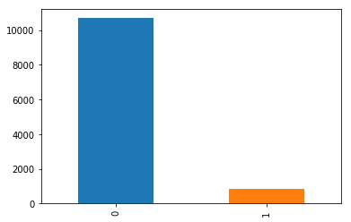

```python
train['result'].value_counts().plot(kind= 'bar')
```

## Pairplots

### Relationships between Counts and Result

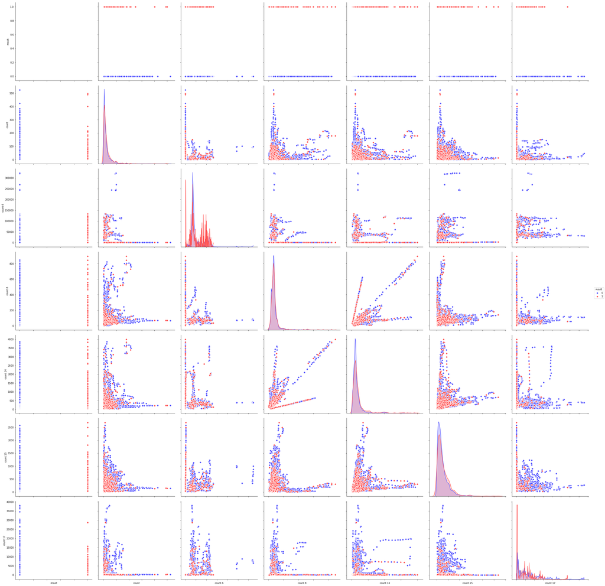

```python
g = sns.pairplot(train[[u'result', u'count',u'count.6', u'count.8', u'count.14', u'count.15', u'count.17']], hue='result', palette = 'seismic',size=5,diag_kind = 'kde',diag_kws=dict(shade=True),plot_kws=dict(s=50) )
g.set(xticklabels=[])
```

### Relationships between Means and Result

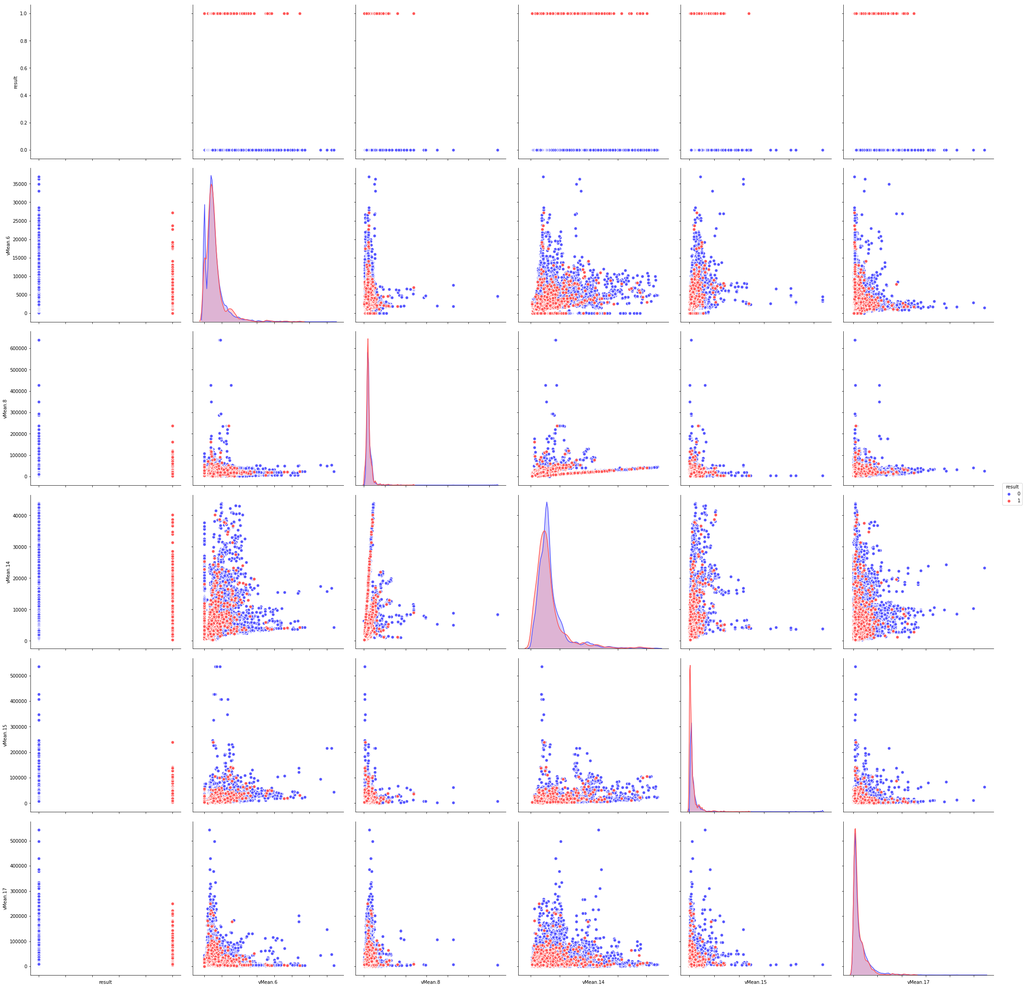

```python
g = sns.pairplot(train[[u'result', u'vMean.6', u'vMean.8', u'vMean.14', u'vMean.15', u'vMean.17']], hue='result', palette = 'seismic',size=5,diag_kind = 'kde',diag_kws=dict(shade=True),plot_kws=dict(s=50) )
g.set(xticklabels=[])
```

### Relationships between Standard Deviations and Result

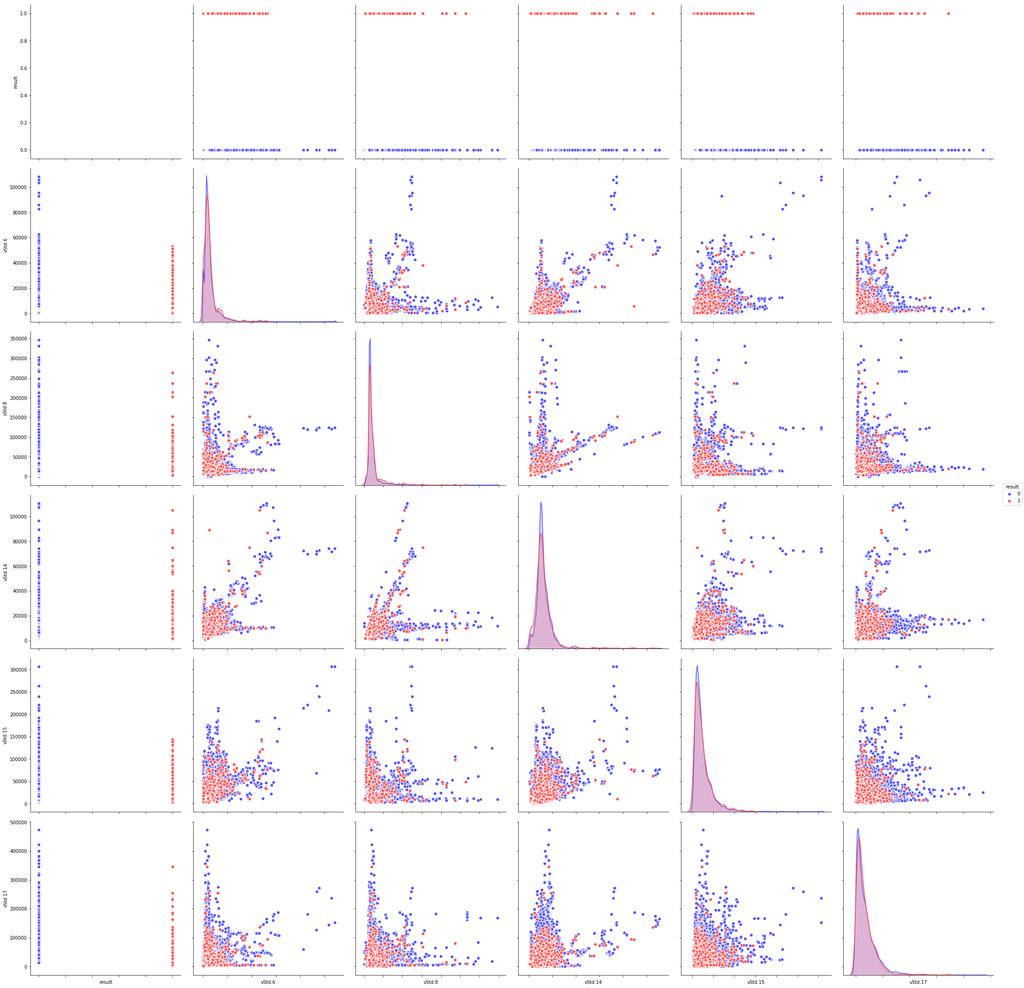

```python
g = sns.pairplot(train[[u'result', u'vStd.6', u'vStd.8', u'vStd.14', u'vStd.15', u'vStd.17']], hue='result', palette = 'seismic',size=5,diag_kind = 'kde',diag_kws=dict(shade=True),plot_kws=dict(s=50) )
g.set(xticklabels=[])
```

## Create a Simple Model and Make the Prediction based on Observations(to be modified)

```python
#feature selection

#choice 1
feature = ["count",\
           "count.6","count.8","count.14","count.15","count.17","count.11","count.20",\
           "vMean.6","vMean.8","vMean.14","vMean.15","vMean.17","vMean.11","vMean.20",\
           "vStd.6","vStd.8","vStd.14","vStd.15","vStd.17","vStd.11","vStd.20",\
           "all_count"]

#choice 2
feature = ["count",\
           "count.6","count.8","count.14","count.15","count.17","count.11","count.20",\
           "vMean.6","vMean.8","vMean.14","vMean.15","vMean.17","vMean.11","vMean.20",\
           "vStd.6","vStd.8","vStd.14","vStd.15","vStd.17","vStd.11","vStd.20"]

linear_regression_used = 0
```

Decision Tree

```python
from sklearn import tree
model = tree.DecisionTreeClassifier()
model.fit(train[feature], train["result"])
predict_data = model.predict(test[feature])
print("finish prediction...")
predict_data_train = model.predict(train[feature])
predict_data_train_frame = pd.DataFrame({
        "result": predict_data_train
        })
print("training accuracy...")
decision_tree_accuracy = accuracy_score(predict_data_train_frame["result"],train["result"])
print(decision_tree_accuracy)
print("training accurate terms count...")
print(accuracy_score(predict_data_train_frame["result"],train["result"],normalize=False))
```

```
finish prediction...
training accuracy...
1.0
training accurate terms count...
11551
```

XGBoost

```python
model = XGBClassifier()
model.fit(train[feature], train["result"])
predict_data = model.predict(test[feature])
print("finish prediction...")
predict_data_train = model.predict(train[feature])
predict_data_train_frame = pd.DataFrame({
        "result": predict_data_train
        })
print("training accuracy...")
xgboost_accuracy = accuracy_score(predict_data_train_frame["result"],train["result"])
print(xgboost_accuracy)
print("training accurate terms count...")
print(accuracy_score(predict_data_train_frame["result"],train["result"],normalize=False))
```

```
finish prediction...
training accuracy...
0.9252878538654662
training accurate terms count...
10688
```

Linear Regression Best Performance: 0.54310

```python
from sklearn import linear_model
model = linear_model.LinearRegression()
linear_regression_used = 1
model.fit(train[feature], train["result"])
predict_data = model.predict(test[feature])
print("finish prediction...")
predict_data_train = model.predict(train[feature])
predict_data_train_frame = pd.DataFrame({
        "result": predict_data_train
        })
predict_data_train_frame.loc[predict_data_train_frame['result'] > 0.0773,'result'] = round(1)
predict_data_train_frame.loc[predict_data_train_frame['result'] <= 0.0773,'result'] = round(0)
print("training accuracy...")
linear_regression_accuracy = accuracy_score(predict_data_train_frame["result"],train["result"])
print(linear_regression_accuracy)
print("training accurate terms count...")
print(accuracy_score(predict_data_train_frame["result"],train["result"],normalize=False))
```

```
finish prediction...
training accuracy...
0.6428014890485673
training accurate terms count...
7425
```

Random Forest

```python
from sklearn.ensemble import RandomForestClassifier
from sklearn.grid_search import GridSearchCV
from sklearn import cross_validation, metrics
model = RandomForestClassifier(n_jobs=-1, random_state=0)
model.fit(train[feature], train["result"])
predict_data = model.predict(test[feature])
print("finish prediction...")
predict_data_train = model.predict(train[feature])
predict_data_train_frame = pd.DataFrame({
        "result": predict_data_train
        })
print("training accuracy...")
random_forest_accuracy = accuracy_score(predict_data_train_frame["result"],train["result"])
print(random_forest_accuracy)
print("training accurate terms count...")
print(accuracy_score(predict_data_train_frame["result"],train["result"],normalize=False))
```

```
finish prediction...
training accuracy...
0.9831183447320578
training accurate terms count...
11356
```

Support Vector Machine

```python
from sklearn import svm
model = svm.SVC()
model.fit(train[feature], train["result"])
predict_data = model.predict(test[feature])
print("finish prediction...")
predict_data_train = model.predict(train[feature])
predict_data_train_frame = pd.DataFrame({
        "result": predict_data_train
        })
print("training accuracy...")
support_vector_accuracy = accuracy_score(predict_data_train_frame["result"],train["result"])
print(support_vector_accuracy)
print("training accurate terms count...")
print(accuracy_score(predict_data_train_frame["result"],train["result"],normalize=False))
```

```
finish prediction...
training accuracy...
1.0
training accurate terms count...
11551
```

Adavanced Support Vector Machine

```python
from sklearn.svm import SVC, LinearSVC
model = SVC(C = 30, gamma = 0.01)
model.fit(train[feature], train["result"])
predict_data = model.predict(test[feature])
print("finish prediction...")
predict_data_train = model.predict(train[feature])
predict_data_train_frame = pd.DataFrame({
        "result": predict_data_train
        })
print("training accuracy...")
advanced_support_vector_accuracy = accuracy_score(predict_data_train_frame["result"],train["result"])
print(advanced_support_vector_accuracy)
print("training accurate terms count...")
print(accuracy_score(predict_data_train_frame["result"],train["result"],normalize=False))
```

```
finish prediction...
training accuracy...
1.0
training accurate terms count...
11551
```

K Clusters

```python
from sklearn.cluster import KMeans
model = KMeans(n_clusters=2, random_state=0)
model.fit(train[feature], train["result"])
predict_data = model.predict(test[feature])
print("finish prediction...")
predict_data_train = model.predict(train[feature])
predict_data_train_frame = pd.DataFrame({
        "result": predict_data_train
        })
print("training accuracy...")
k_clusters_accuracy = accuracy_score(predict_data_train_frame["result"],train["result"])
print(k_clusters_accuracy)
print("training accurate terms count...")
print(accuracy_score(predict_data_train_frame["result"],train["result"],normalize=False))
```

```
finish prediction...
training accuracy...
0.8749891784261103
training accurate terms count...
10107
```

K Nearest Neighbours

```python
from sklearn.neighbors import KNeighborsClassifier
model = KNeighborsClassifier(n_neighbors=20)
model.fit(train[feature], train["result"])
predict_data = model.predict(test[feature])
print("finish prediction...")
predict_data_train = model.predict(train[feature])
predict_data_train_frame = pd.DataFrame({
        "result": predict_data_train
        })
print("training accuracy...")
k_nearest_neighbours_accuracy = accuracy_score(predict_data_train_frame["result"],train["result"])
print(k_nearest_neighbours_accuracy)
print("training accurate terms count...")
print(accuracy_score(predict_data_train_frame["result"],train["result"],normalize=False))
```

```
finish prediction...
training accuracy...
0.9251147086832309
training accurate terms count...
10686
```

# Conclusion

### Model evaluation

The comparison among training accuracy of different models is shown below:

```python
models = pd.DataFrame({
    'Model': ['Decision Tree','XGBoost','Linear Regression','Random Forest','Support Vector Machine','Advanced Support Vector Machine', 'K Clusters','K Nearest Neighbours'],
    'Training accuracy': [decision_tree_accuracy, xgboost_accuracy, linear_regression_accuracy,random_forest_accuracy, support_vector_accuracy, advanced_support_vector_accuracy, k_clusters_accuracy, k_nearest_neighbours_accuracy]})
models.sort_values(by='Training accuracy', ascending=False)
```

|  | Model | Training accuracy |
| --- | --- | --- |
| 0 | Decision Tree | 1.000000 |
| 4 | Support Vector Machine | 1.000000 |
| 5 | Advanced Support Vector Machine | 1.000000 |
| 3 | Random Forest | 0.983118 |
| 1 | XGBoost | 0.925288 |
| 7 | K Nearest Neighbours | 0.925115 |
| 6 | K Clusters | 0.874989 |
| 2 | Linear Regression | 0.642801 |

As shown above, although many models show high traning accuracy, there're still overfitting.

And one interesting finding is that although Linear Regression has a worst training accuracy on the above list, it has the best performance on the Kaggle contest. All other methods will only attain an accuracy around 0.49~0.51.

Analysis: We may notice that there are several predicting methods can reach 100% accuracy on the training set. That should be good according to our past experience. However, the reason why we don't use these methods is that they are in serious overfitting situations.The number of dimensions is relatively large for this dataset, so it is easier to overfit into the training dataset.

Reason: We may find the reason from the performance of all methods. There is a phenomenon. With a method other than the linear regression model, they will provide a prediction result filled with almost all 0. And for a linear regression model, most of the prediction results are in range of 0 to 0.15.

This means that the True label will be not that obvious to derive from the features. The data together can only provide a weak prediction on the result. They are strong proofs for "False". It is hard for them to get to a state with a high confidence to label it as "True". In order to solve this problem, we may need to adjust the threshold to get more "True" as results.

Finally we come up with a linear regression model with the threshold set to 0.075. This value can provide an accuracy rate of 0.54310.

Above all, we evetually choose the linear regression model to finish and sumit the pridiction.

# Make Submission

```python
print("final wrap up...")
submission = pd.DataFrame({
        "id": (test["Machine"]+"-"+test["Date"]),
        "Label": predict_data
        })

#used for linear regression
if(linear_regression_used > 0.5):
    submission.loc[submission['Label'] > 0.075,'Label'] = round(1)
    submission.loc[submission['Label'] <= 0.075,'Label'] = round(0)


print("write to file...")
submission.to_csv("submission.csv",columns=["id","Label"],index = False)
```

```
final wrap up...
write to file...
```